# hw#6.data624

# b. Plot forecasts from an ARIMA(0,1,1) model with no drift and compare these to part a. Remove the MA term and plot again.

Ljung-Box test for both models suggests we fail to reject null hypothesis of residuals being white noise, (the residuals have constant variance). The residuals also look normally distributed.

Thus, we can conclude that our models can forecast reliably.

The forecast plot in b. shows that there will be a flat trend in the next 10 periods, which is different from a. where there was increasing trend.

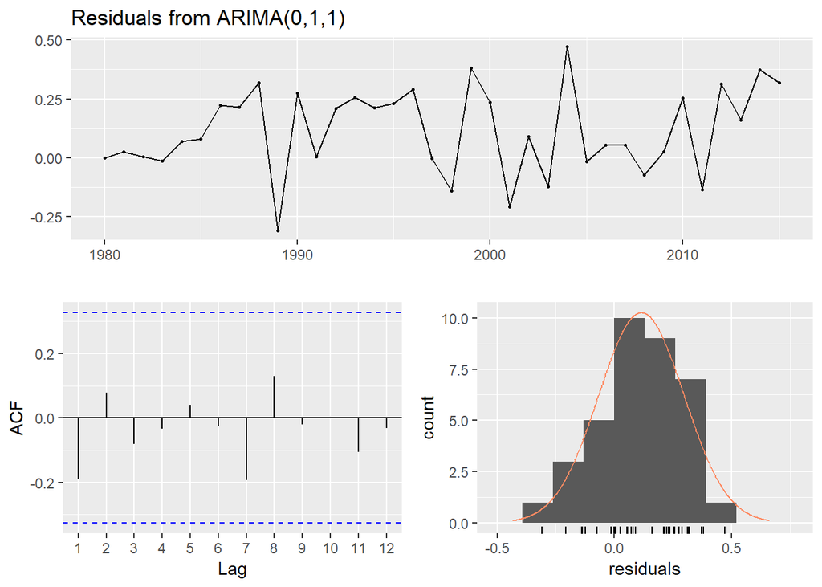

```
##
##  Ljung-Box test
##
## data:  Residuals from ARIMA(0,1,1)
## Q* = 3.8403, df = 6, p-value = 0.6983
##
## Model df: 1.   Total lags used: 7
```

```r
model2 <- Arima(austa, order = c(0,1,1), include.drift = FALSE)
checkresiduals(model2)
```

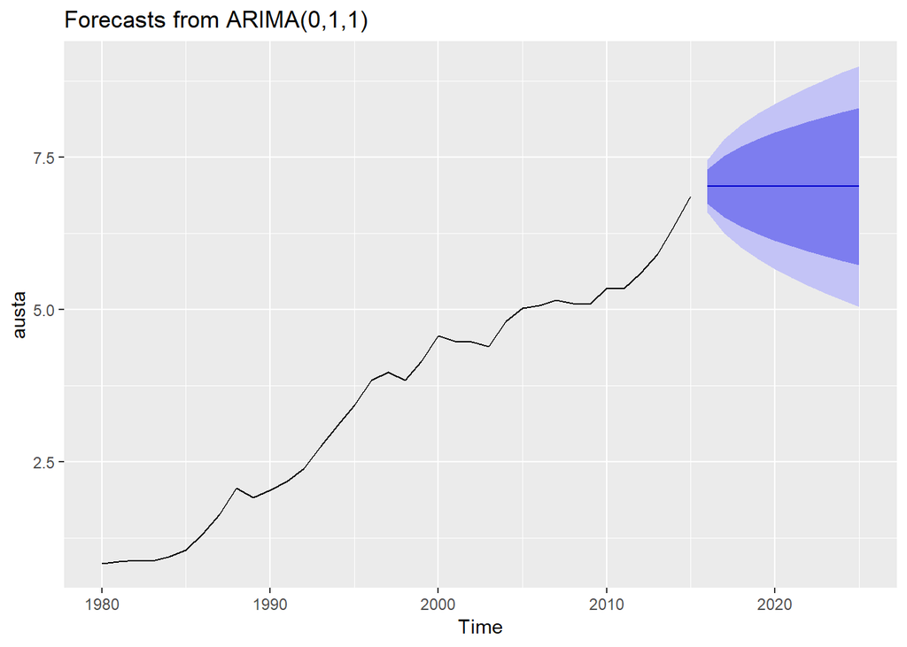

```r
pred2 <- forecast(model2, h = 10)
autoplot(pred2)
```

```r
summary(pred2)
```

```
##
## Forecast method: ARIMA(0,1,1)
##
## Model Information:
## Series: austa
## ARIMA(0,1,1)
##
## Coefficients:
##          ma1
##       0.4936
## s.e.  0.1265
##
## sigma^2 estimated as 0.04833:  log likelihood=3.73
## AIC=-3.45   AICc=-3.08   BIC=-0.34
##
## Error measures:
##                     ME      RMSE       MAE      MPE     MAPE      MASE
## Training set 0.1150344 0.2136411 0.1714887 3.817629 5.649995 0.8416532
##                    ACF1
## Training set -0.1892256
##
## Forecasts:
##      Point Forecast    Lo 80    Hi 80    Lo 95    Hi 95
## 2016       7.015837 6.734107 7.297567 6.584969 7.446705
## 2017       7.015837 6.509440 7.522234 6.241369 7.790305
## 2018       7.015837 6.357426 7.674248 6.008885 8.022789
## 2019       7.015837 6.234446 7.797228 5.820803 8.210871
## 2020       7.015837 6.128347 7.903327 5.658539 8.373135
## 2021       7.015837 6.033643 7.998031 5.513701 8.517973
## 2022       7.015837 5.947300 8.084374 5.381651 8.650023
## 2023       7.015837 5.867430 8.164244 5.259501 8.772173
## 2024       7.015837 5.792765 8.238909 5.145310 8.886364
## 2025       7.015837 5.722403 8.309271 5.037701 8.993973
```

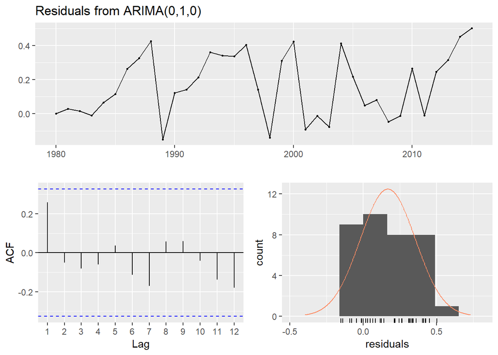

```
##
##  Ljung-Box test
##
## data:  Residuals from ARIMA(0,1,0)
## Q* = 5.1592, df = 7, p-value = 0.6405
##
## Model df: 0.   Total lags used: 7
```

```r
model3 <- Arima(austa, order = c(0,1,0), include.drift = FALSE)
checkresiduals(model3)
```

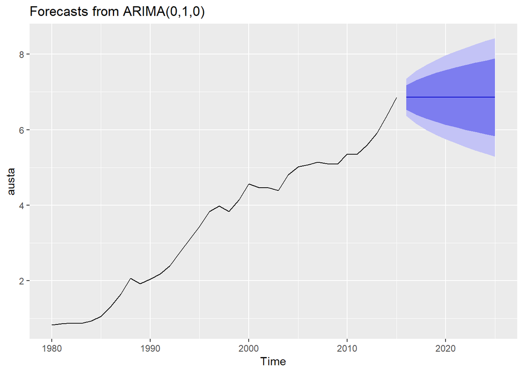

```r
pred3 <- forecast(model3, h = 10)
autoplot(pred3)
```

```r
summary(pred3)
```

```
##
## Forecast method: ARIMA(0,1,0)
##
## Model Information:
## Series: austa
## ARIMA(0,1,0)
##
## sigma^2 estimated as 0.06423:  log likelihood=-1.62
## AIC=5.24   AICc=5.36   BIC=6.8
##
## Error measures:
##                     ME      RMSE       MAE      MPE     MAPE      MASE
## Training set 0.1674969 0.2498996 0.1981155 5.471861 6.479997 0.9723354
##                   ACF1
## Training set 0.2583422
##
## Forecasts:
##      Point Forecast    Lo 80    Hi 80    Lo 95    Hi 95
## 2016       6.858953 6.534151 7.183755 6.362211 7.355695
## 2017       6.858953 6.399614 7.318292 6.156454 7.561452
## 2018       6.858953 6.296379 7.421527 5.998571 7.719335
## 2019       6.858953 6.209349 7.508557 5.865469 7.852437
## 2020       6.858953 6.132673 7.585233 5.748204 7.969702
## 2021       6.858953 6.063354 7.654552 5.642189 8.075717
## 2022       6.858953 5.999607 7.718299 5.544697 8.173209
## 2023       6.858953 5.940274 7.777632 5.453955 8.263951
## 2024       6.858953 5.884547 7.833359 5.368727 8.349179
## 2025       6.858953 5.831839 7.886067 5.288117 8.429789
```

# c. Plot forecasts from an ARIMA(2,1,3) model with drift. Remove the constant and see what happens.

Given that d > 0 already, constant is omitted from the beginning but I applied it anyway. Method needs to be changed to Maximum-likelihood or CSS. Otherwise, Arima() gives you an error message.

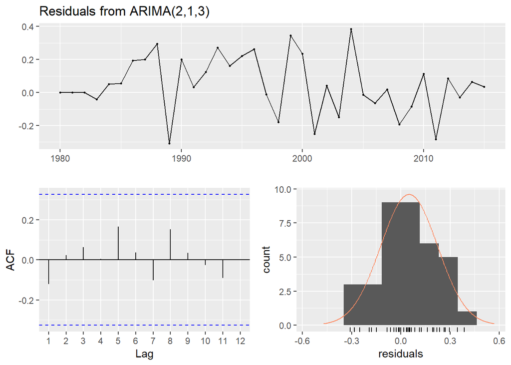

```
##
##  Ljung-Box test
##
## data:  Residuals from ARIMA(2,1,3)
## Q* = 3.634, df = 3, p-value = 0.3038
##
## Model df: 5.   Total lags used: 8
```

```r
model4 <- Arima(austa, order = c(2,1,3), include.constant = FALSE, method = 'CSS')
checkresiduals(model4)
```

```r
pred4 <- forecast(model4, h = 10)
```

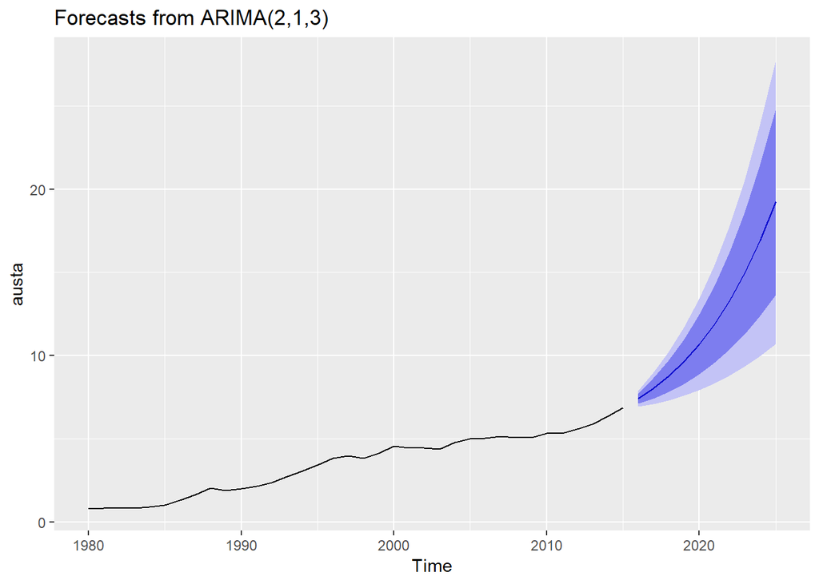

```r
autoplot(pred4)
```

```r
summary(pred4)
```

```
##
## Forecast method: ARIMA(2,1,3)
##
## Model Information:
## Series: austa
## ARIMA(2,1,3)
##
## Coefficients:
##          ar1     ar2      ma1      ma2      ma3
##       0.5138  0.7818  -0.1307  -0.9960  -0.4001
## s.e.  0.3718  0.5367   0.4625   0.5151   0.3345
##
## sigma^2 estimated as 0.03799:  part log likelihood=9.24
##
## Error measures:
##                      ME      RMSE       MAE      MPE     MAPE      MASE
## Training set 0.04981184 0.1779344 0.1390249 2.155024 4.803313 0.6823234
##                    ACF1
## Training set -0.1202229
##
## Forecasts:
##      Point Forecast     Lo 80     Hi 80     Lo 95     Hi 95
## 2016       7.416168  7.111898  7.720437  6.950828  7.881508
## 2017       8.036829  7.415544  8.658113  7.086655  8.987002
## 2018       8.778174  7.819677  9.736671  7.312279 10.244069
## 2019       9.644357  8.308738 10.979975  7.601705 11.687009
## 2020      10.669041  8.886710 12.451371  7.943201 13.394880
## 2021      11.872771  9.565477 14.180064  8.344070 15.401471
## 2022      13.292422 10.361632 16.223213  8.810165 17.774679
## 2023      14.963006 11.294913 18.631099  9.353142 20.572870
## 2024      16.931343 12.389743 21.472942  9.985566 23.877119
## 2025      19.248862 13.674560 24.823164 10.723703 27.774021
```

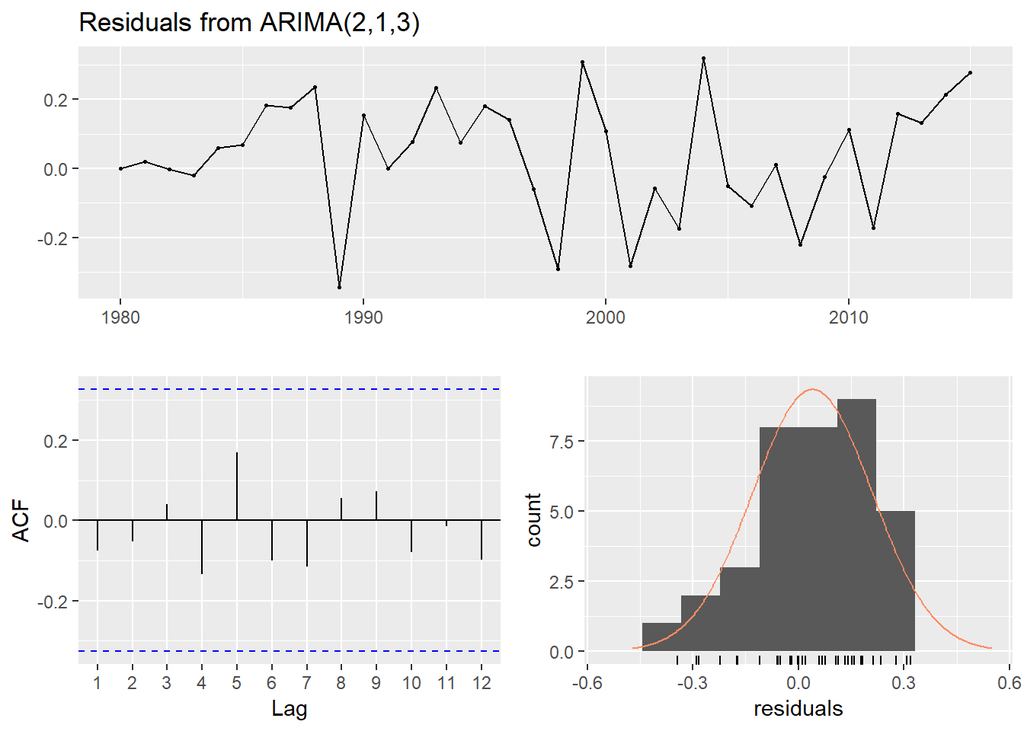

```
##
##  Ljung-Box test
##
## data:  Residuals from ARIMA(2,1,3)
## Q* = 3.6694, df = 3, p-value = 0.2994
##
## Model df: 5.   Total lags used: 8
```

```r
model4 <- Arima(austa, order = c(2,1,3), include.constant = FALSE, method = 'ML')
checkresiduals(model4)
```

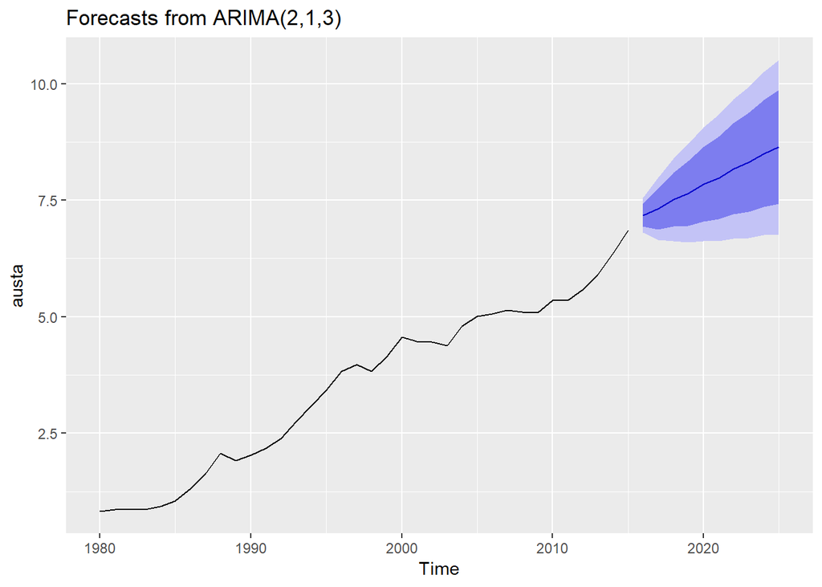

```r
pred4 <- forecast(model4, h = 10)
autoplot(pred4)
```

```r
summary(pred4)
```

```
##
## Forecast method: ARIMA(2,1,3)
##
## Model Information:
## Series: austa
## ARIMA(2,1,3)
##
## Coefficients:
##          ar1     ar2     ma1      ma2      ma3
##       0.0004  0.9996  0.4633  -0.9893  -0.4625
## s.e.  0.0031  0.0031  0.2283   0.0329   0.2261
##
## sigma^2 estimated as 0.03568:  log likelihood=9.24
## AIC=-6.48   AICc=-3.48   BIC=2.85
##
## Error measures:
##                      ME      RMSE       MAE      MPE     MAPE      MASE
## Training set 0.03972287 0.1724412 0.1402048 1.685829 4.592996 0.6881143
##                     ACF1
## Training set -0.07513543
##
## Forecasts:
##      Point Forecast    Lo 80    Hi 80    Lo 95     Hi 95
## 2016       7.178948 6.932158 7.425739 6.801515  7.556382
## 2017       7.316096 6.877422 7.754770 6.645201  7.986991
## 2018       7.510224 6.933117 8.087331 6.627615  8.392833
## 2019       7.647387 6.956180 8.338593 6.590278  8.704496
## 2020       7.841488 7.046627 8.636348 6.625853  9.057122
## 2021       7.978666 7.090007 8.867325 6.619579  9.337753
## 2022       8.172740 7.194381 9.151099 6.676469  9.669011
## 2023       8.309934 7.247714 9.372154 6.685409  9.934459
## 2024       8.503981 7.359766 9.648197 6.754055 10.253908
## 2025       8.641190 7.419069 9.863312 6.772117 10.510264
```

# d. Plot forecasts from an ARIMA(0,0,1) model with a constant. Remove the MA term and plot again.

Note that both of them have residuals that does not resemble white noise series. Residuals do not have normally distributed shape. Both constant variance and nomarlity assumptions are not met and hence the models are not reliable in prediction. Note that in 0,0,0, point forecast starts in flat trend where as 0,0,1 becomes flat trend at h > 1.

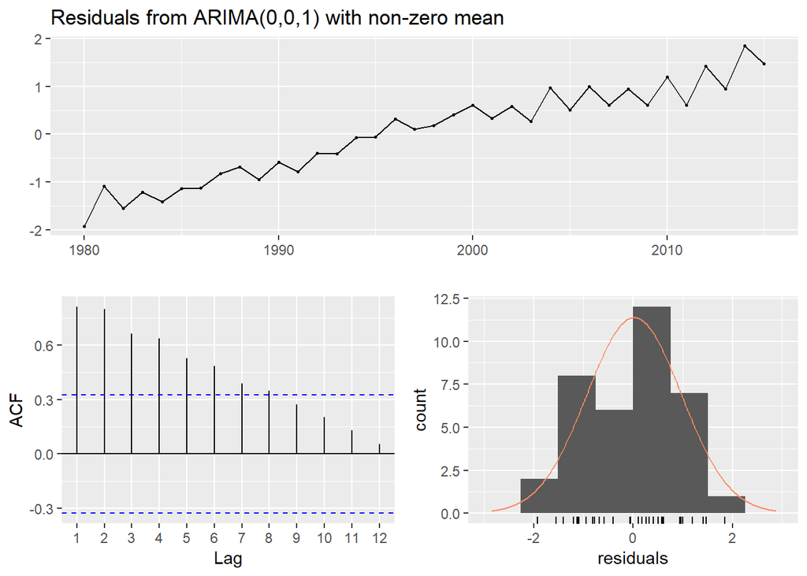

```
##
##  Ljung-Box test
##
## data:  Residuals from ARIMA(0,0,1) with non-zero mean
## Q* = 116.97, df = 5, p-value < 2.2e-16
##
## Model df: 2.   Total lags used: 7
```

```r
model5 <- Arima(austa, order = c(0,0,1), include.constant = TRUE)
checkresiduals(model5)
```

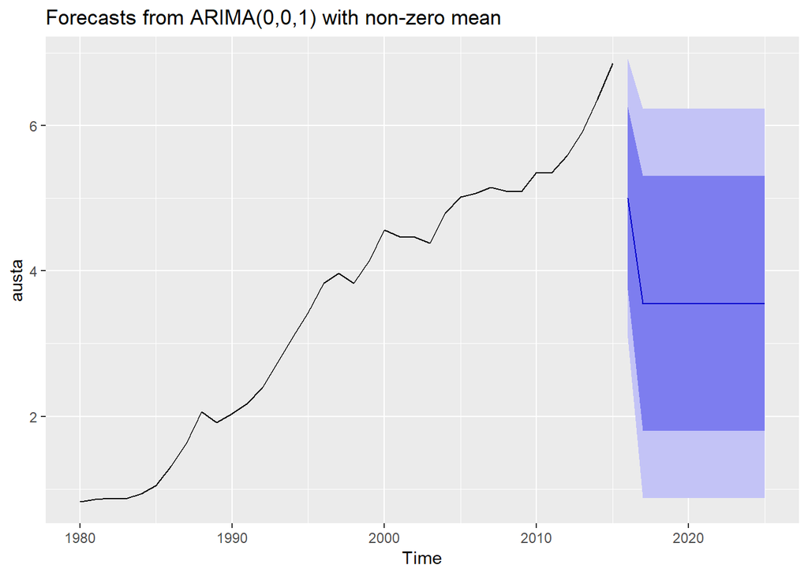

```r
pred5 <- forecast(model5, h = 10)
autoplot(pred5)
```

```r
summary(pred5)
```

```
##
## Forecast method: ARIMA(0,0,1) with non-zero mean
##
## Model Information:
## Series: austa
## ARIMA(0,0,1) with non-zero mean
##
## Coefficients:
##          ma1    mean
##       1.0000  3.5515
## s.e.  0.0907  0.3090
##
## sigma^2 estimated as 0.9347:  log likelihood=-50.64
## AIC=107.28   AICc=108.03   BIC=112.04
##
## Error measures:
##                      ME      RMSE       MAE       MPE     MAPE     MASE
## Training set 0.01997167 0.9395462 0.8063899 -26.87733 42.56419 3.957698
##                   ACF1
## Training set 0.8109528
##
## Forecasts:
##      Point Forecast    Lo 80    Hi 80    Lo 95    Hi 95
## 2016       4.997220 3.741604 6.252836 3.076921 6.917519
## 2017       3.551491 1.799302 5.303680 0.871749 6.231232
## 2018       3.551491 1.799302 5.303680 0.871749 6.231232
## 2019       3.551491 1.799302 5.303680 0.871749 6.231232
## 2020       3.551491 1.799302 5.303680 0.871749 6.231232
## 2021       3.551491 1.799302 5.303680 0.871749 6.231232
## 2022       3.551491 1.799302 5.303680 0.871749 6.231232
## 2023       3.551491 1.799302 5.303680 0.871749 6.231232
## 2024       3.551491 1.799302 5.303680 0.871749 6.231232
## 2025       3.551491 1.799302 5.303680 0.871749 6.231232
```

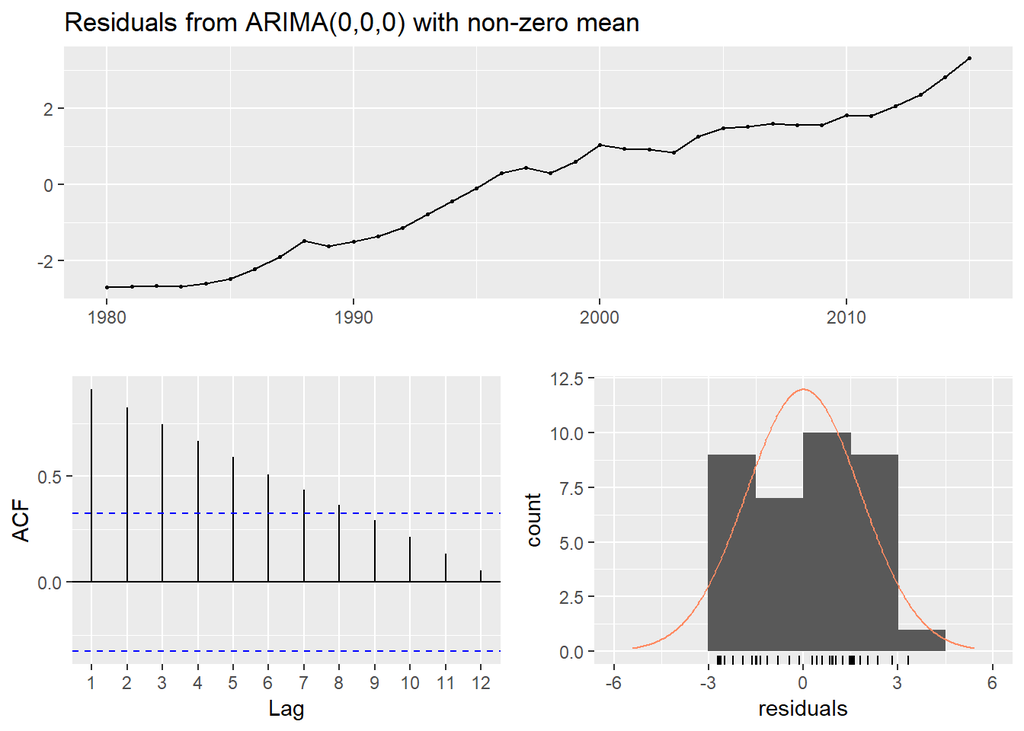

```
##
##  Ljung-Box test
##
## data:  Residuals from ARIMA(0,0,0) with non-zero mean
## Q* = 137.9, df = 6, p-value < 2.2e-16
##
## Model df: 1.   Total lags used: 7
```

```r
model6 <- Arima(austa, order = c(0,0,0), include.constant = TRUE)
checkresiduals(model6)
```

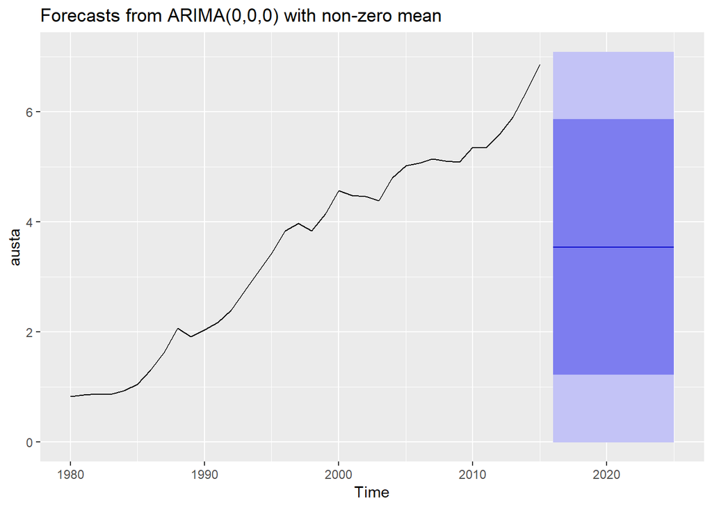

```r
pred6 <- forecast(model6, h = 10)
autoplot(pred6)
```

```r
summary(pred6)
```

```
##
## Forecast method: ARIMA(0,0,0) with non-zero mean
##
## Model Information:
## Series: austa
## ARIMA(0,0,0) with non-zero mean
##
## Coefficients:
##         mean
##       3.5414
## s.e.  0.2972
##
## sigma^2 estimated as 3.27:  log likelihood=-71.9
## AIC=147.8   AICc=148.17   BIC=150.97
##
## Error measures:
##                       ME     RMSE      MAE       MPE     MAPE     MASE
## Training set 5.00254e-13 1.783072 1.580774 -52.92811 82.83469 7.758317
##                   ACF1
## Training set 0.9099807
##
## Forecasts:
##      Point Forecast    Lo 80    Hi 80        Lo 95    Hi 95
## 2016       3.541428 1.223915 5.858941 -0.002902594 7.085758
## 2017       3.541428 1.223915 5.858941 -0.002902594 7.085758
## 2018       3.541428 1.223915 5.858941 -0.002902594 7.085758
## 2019       3.541428 1.223915 5.858941 -0.002902594 7.085758
## 2020       3.541428 1.223915 5.858941 -0.002902594 7.085758
## 2021       3.541428 1.223915 5.858941 -0.002902594 7.085758
## 2022       3.541428 1.223915 5.858941 -0.002902594 7.085758
## 2023       3.541428 1.223915 5.858941 -0.002902594 7.085758
## 2024       3.541428 1.223915 5.858941 -0.002902594 7.085758
## 2025       3.541428 1.223915 5.858941 -0.002902594 7.085758
```

# e. Plot forecasts from an ARIMA(0,2,1) model with no constant.

Ljung-Box test confirms residuals are white noise and therefore, model is a reliable predictor. Note that for this model has an increasing trend in forecast.

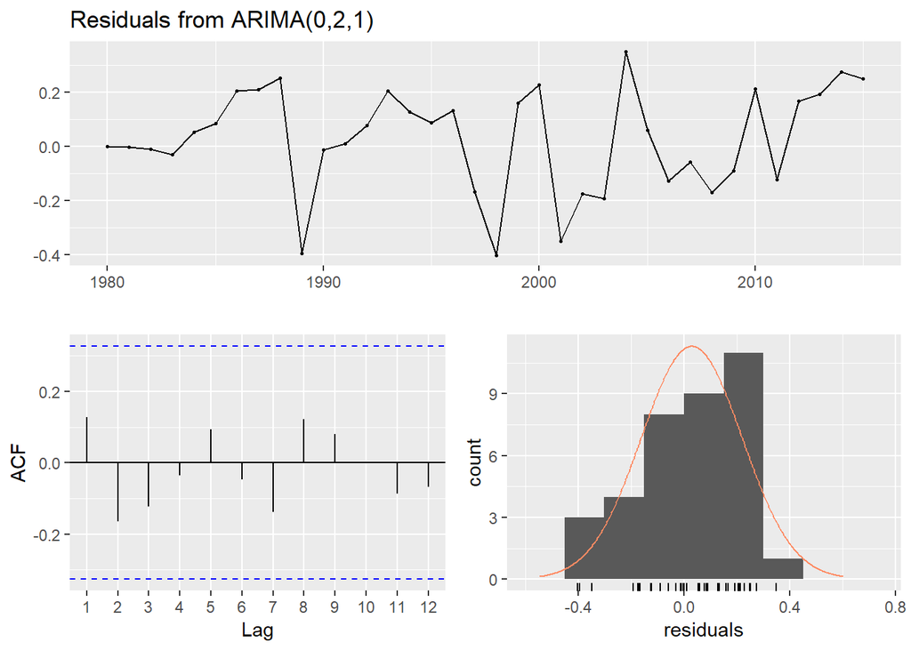

```
##
##  Ljung-Box test
##
## data:  Residuals from ARIMA(0,2,1)
## Q* = 3.8054, df = 6, p-value = 0.703
##
## Model df: 1.   Total lags used: 7
```

```r
model7 <- Arima(austa, order = c(0,2,1), include.constant = FALSE)
checkresiduals(model7)
```

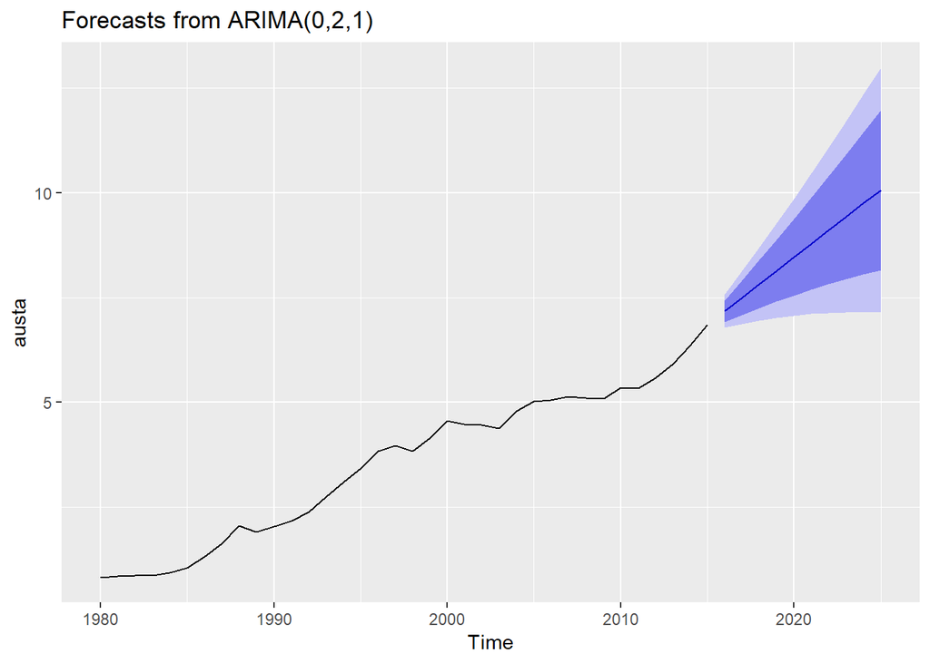

```r
pred7 <- forecast(model7, h = 10)
autoplot(pred7)
```

```r
summary(pred7)
```

```
##
## Forecast method: ARIMA(0,2,1)
##
## Model Information:
## Series: austa
## ARIMA(0,2,1)
##
## Coefficients:
##           ma1
##       -0.7263
## s.e.   0.2277
##
## sigma^2 estimated as 0.03969:  log likelihood=6.74
## AIC=-9.48   AICc=-9.09   BIC=-6.43
##
## Error measures:
##                      ME      RMSE       MAE      MPE     MAPE      MASE
## Training set 0.02907781 0.1907537 0.1567877 1.216128 4.984081 0.7695018
##                   ACF1
## Training set 0.1284994
##
## Forecasts:
##      Point Forecast    Lo 80     Hi 80    Lo 95     Hi 95
## 2016       7.179291 6.923960  7.434622 6.788796  7.569786
## 2017       7.499628 7.086148  7.913108 6.867265  8.131992
## 2018       7.819966 7.248051  8.391881 6.945297  8.694634
## 2019       8.140304 7.403196  8.877411 7.012995  9.267612
## 2020       8.460641 7.549896  9.371387 7.067776  9.853506
## 2021       8.780979 7.687705  9.874253 7.108960 10.452997
## 2022       9.101316 7.816610 10.386023 7.136527 11.066106
## 2023       9.421654 7.936765 10.906543 7.150712 11.692596
## 2024       9.741992 8.048388 11.435595 7.151848 12.332135
## 2025      10.062329 8.151718 11.972940 7.140302 12.984357
```